# UKBB summary statistics from Neale lab

Andrey Ziyatdinov

Dec, 2018

## We need UKBB for reliable large-scale fine-mapping

The Neale lab released a UKBB GWAS summary statistics repository and made it publicly available at http://www.nealelab.is/uk-biobank/.

To query this resource, we created the sumstats R package (currently, not public).

Here, we show what results are for SCC/BCC disease outcomes.

## UKBB GWAS protocol from Neale lab

Source: [blog post](http://www.nealelab.is/blog/2017/9/11/details-and-considerations-of-the-uk-biobank-gwas)

> We further restricted to SNPs with minor allele frequency (MAF) > 0.1% and HWE p-value > 1e-10 in the 337,199 QC positive individuals, an INFO score > 0.8 (directly from UK Biobank), leaving 10.8 million SNPs for analysis.

Some steps important for case-control analysis:

1. Linear model is applied
2. SNPs are filtered based on
   - expected_case_minor_AC < 25 or
   - minor_AF < 0.001

Remember that the filter 2. is missing in SCC meta-analysis, which might be likely the source of spurious associations.

## Defintion of SCC cases: included in BCC cases

UKBB showcase: http://biobank.ctsu.ox.ac.uk/crystal/field.cgi?id=20001

| phenotype | description | variable_type | source |
| --- | --- | --- | --- |
| 20001_1061 | Cancer code, self-reported: basal cell carcinoma | binary | phesant |
| 20001_1062 | Cancer code, self-reported: squamous cell carcinoma | binary | phesant |

| n_non_missing | n_missing | n_controls | n_cases | n_eff |
| --- | --- | --- | --- | --- |
| 361,141 | 53 | 357,700 | 3,441 | 13,633 |
| 361,141 | 53 | 360,692 | 449 | 1,794 |

In comparision to our SCC meta-analysis:

| cohort | case | control | num_samples_eff |
| --- | --- | --- | --- |
| Harvard | 2,293 | 33,008 | 8,576 |
| 23me | 6,579 | 280,558 | 25,713 |

## BCC GWAS in UKBB (Neff = 13,633)

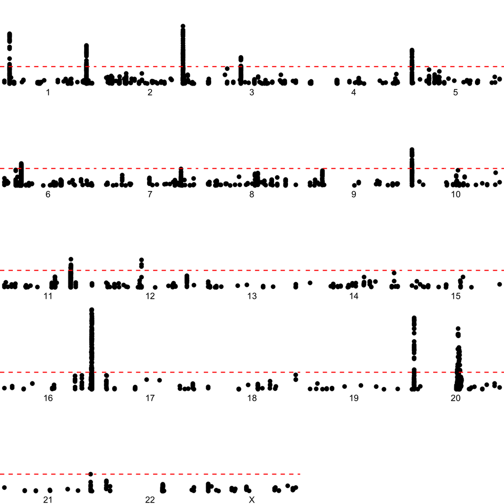

The top SNP rs1805007 (16:89986117) is associated with Tanning, Skin sensitivity to sun, Sunburns, **Basal cell carcinoma**, Blond vs. brown hair color, **Non-melanoma skin cancer**, Hair color (source: [GWAS catalog, 2015](https://github.com/igvteam/igv.js/blob/master/test/data/misc/GWAS_catalog_SNPs_Pval5E08_hg19_040115_subset.txt))

The locus within rs1805007 variant exhibits a high allelic heterogeneity in our GCTA-COJO analysis of SCC meta-summary statistics (24 signals). Replicate in UKBB BCC-GWAS?

|  | pos | pval (ukbb) | pval (meta) | gene context |
| --- | --- | --- | --- | --- |
| rs1805007 | 16:89986117 | 3.7e-20 | 1.4e-87 | TCF25-[]-TUBB3 |

## SCC GWAS in UKBB (Neff = 1,794)

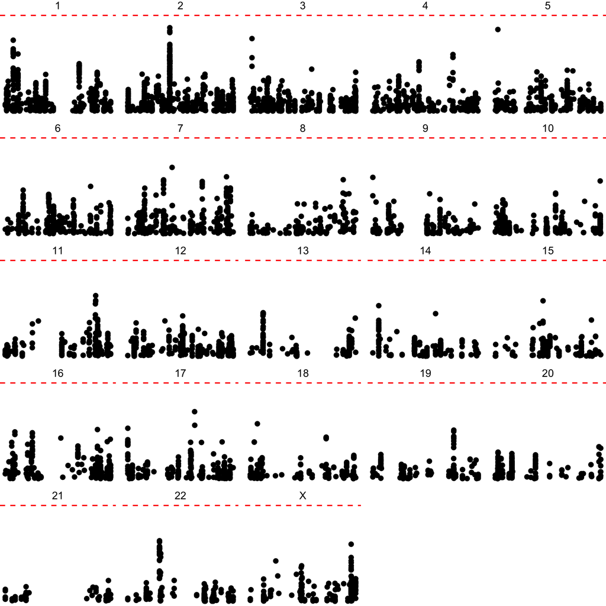

## Next steps

Next, we want to implement LD computation in UKBB (seems to be recognized as a research bioinf. problem) accessing to the raw data.

We might also want to refine the case-control GWAS (logistic regression).

After that, we can follow the Sara Pulit’s [protocol](https://docs.google.com/document/d/18ocKNrrQ1lFQMRQBGaJFErdDf3ulFiUn3ZnWjexJcOg/edit?usp=sharing).